# Er det høyde som bestemmer inntekt?

Kine Maakestad

Susann Sivertsen

# Introduksjon

I denne oppgaven skal vi finne ut om høyde bestemmer inntekten til personer. Først skriver vi en liten kort litteraturgjennomgang, samt beskrivende statistikk. Deretter har vi analysert om høyde bestemmer inntekten. Til slutt konkluderer vi om dette stemmer.

# Kort litteraturgjennomgang

**The Effect of Physical Height on Workplace Success and Income: Preliminary Test of a Theoretical Model, av Judge and Cable (2004).**

Artikkelen ser på relasjonen mellom karrieresuksess og fysisk høyde. Det baseres på en meta-analyse av litteraturen, hvor resultatene viser mot at høyde er relatert til hvordan andre ser deg, ledermuligheter og opptreden. Artikkelen viser også til at høyde har er sterkere relasjon til karriere suksess for menn enn for kvinner, men denne forskjellen sees ikke på som signifikant. Ettersom det ikke finnes forskning på forholdet mellom høyde og inntekt, brukes det fire steg som tilsier at høyde er positivt for inntekt etter at det er tatt hensyn til kjønn, alder og vekt. Artikkelen tar for seg en omfattende analyse av relasjonen mellom høyde og karrière suksess, og resultatene tilsier at høye individer har et fortrinn i viktige aspekter av deres karrierer.

Artikkelen baseres på samfunnets inntrykk av at høye folk er mer suksessfulle. Dette går tilbake til dyreverden hvor høyde er en indeks for makt og styrke i kritiske situasjoner. Artikkelen viser til at høyde burde være relevant i arbeidsmiljø hvor overtalelse og og makt er signifikant. Høyde påvirker ikke bare hvordan andre ser deg, men kan også påvirke hvordan du ser deg selv, og personers psykologiske tilpasning og selvtilit. Et resultat av de to faktorene vil igjen påvirke opptreden som videre påvirker karriere suksess (Judge and Cable 2004).

De fire studiene nevnt i artikkelen viser alle til at det er en positiv korrelasjon mellom høyde og inntekt. Det konkluderes videre med at effekten til ens høyde ikke svekkes over tid, altså senere i ens karriere, men derimot øker litt. Videre i artikkelen diskuteres det igjen om effekten av høyde varierer basert på ulike typer yrker. Det generelle resultatet av dette var at sosiale yrker, med mye interaksjoner, avhenger mer av utseende og dermed høyde enn mindre sosiale yrker (Judge and Cable 2004).

Denne artikkelen viser tydelig til at fysisk høyde påvirker karrierer og interaksjoner og at en videre forsking burde gjøres på dette. Ettersom det teoretisk er viktig for å skjønne hvorfor og hvordan det har effekt på suksess og inntekt. Og praktisk fordi at ledere lettere kan få en forståelse på om høyde påvirker suksess via hvordan andre ser deg, og ens egen selvtilit eller om det påvirker suksess helt uavhengig av andre faktorer (Judge and Cable 2004).

# Beskrivende statistikk

Beskrivende statistikk av datasettet “heights” er:

- **heights** = er høyde i tommer
- **income** = årlig inntekt. Top 2% gjennomsnitt av verdien og gjennomsnittet er brukt til å erstatte alle verdiene i topp inntekten.
- **weight** = det er vekten i pounds
- **age** = alder i år, mellom 47 og 56
- **martial** = sivilstatus
- **sex** = kjønn
- **education** = hvor mange år utdannelse
- **afgt** = persentilscore på Forsvarets kvalifikasjonsprøve

# Analyse:

For analyse delen lager vi først et histogram med variabelen inntekt. Vi har gjort om inntekt, høyde og vekt til metrisk standard. Som vil si at inntekten blir gjort om til norske kroner, høyde i cm og vekten i kg. Videre lager vi ulike modeller for å teste påstanden om høyde har en påvirkning på inntekt.

## EDA av datasett

Her er variablene gjort om til metrisk standard. Det er også lagt til tre nye variabler.

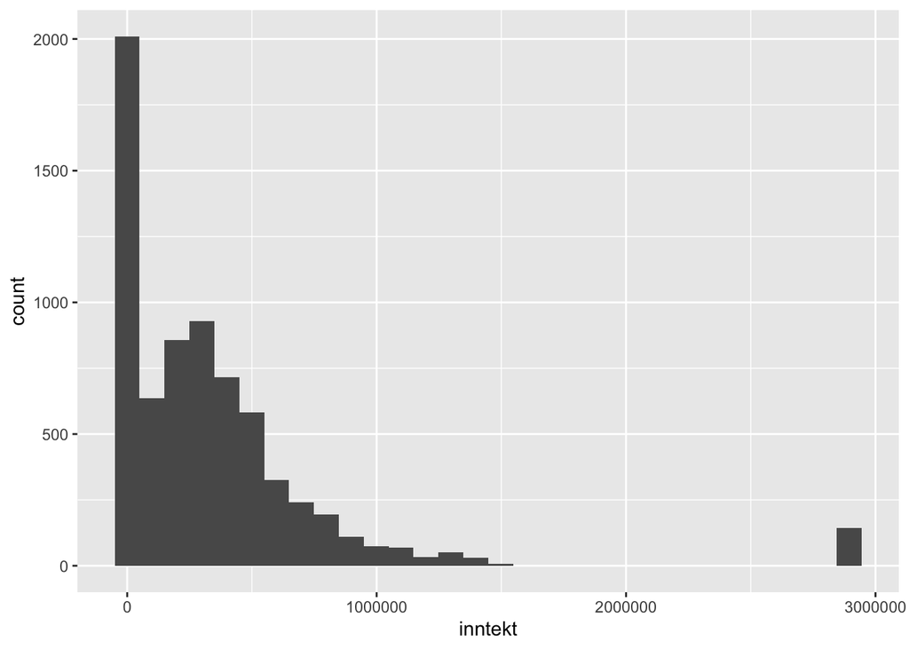

I histogrammet ovenfor ser man at utliggerne ligger veldig langt til høyre. Grunnen til dette er fordi det er funnet gjennomsnittet inkludert topp 2% inntekt.

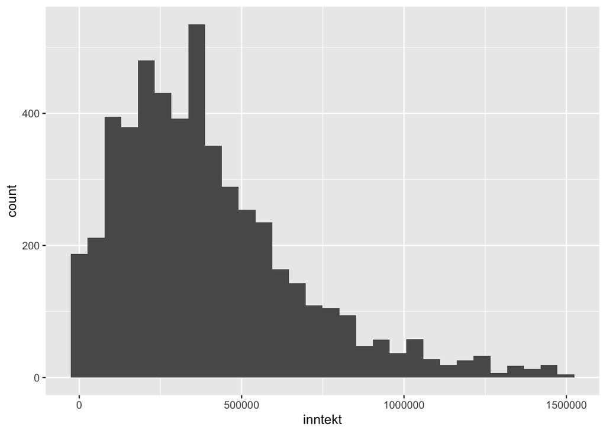

I dette histogrammet utelukker man topp 2% og personer uten inntekt.

```
## [1] 1740
```

Summen av personer som er tatt med i datasettet uten inntekt er på 1740 stykk.

## Regresjonsanalyse

```
##
## Call:
## lm(formula = mod1, data = hoyde, subset = complete.cases(hoyde))
##
## Residuals:
##     Min      1Q  Median      3Q     Max
## -782810 -267359  -94513  123099 2699234
##
## Coefficients:
##               Estimate Std. Error t value Pr(>|t|)
## (Intercept) -1361001.0    94430.0  -14.41   <2e-16 ***
## hoyde_cm       10047.9      552.8   18.18   <2e-16 ***
## ---
## Signif. codes:  0 '***' 0.001 '**' 0.01 '*' 0.05 '.' 0.1 ' ' 1
##
## Residual standard error: 467300 on 6643 degrees of freedom
## Multiple R-squared:  0.04737,    Adjusted R-squared:  0.04723
## F-statistic: 330.3 on 1 and 6643 DF,  p-value: < 2.2e-16
```

```
## [1] 377285.7
```

```
## [1] 256710.9
```

Utfra denne modellen ser man at inntekten øker med 10047.9 kr per cm man øker i høyde. Med utgangspunkt i modellen er det her et eksempel tatt med på at dersom en person er 173 cm høy vil forventet inntekt være på 377.285,7 kr, mens dersom personen er 161 cm vil forventet inntekt være bare 256.710,9 kr.

```
##
## Call:
## lm(formula = mod2, data = hoyde, subset = complete.cases(hoyde))
##
## Residuals:
##     Min      1Q  Median      3Q     Max
## -843668 -263322  -92573  125798 2715000
##
## Coefficients:
##               Estimate Std. Error t value   Pr(>|t|)
## (Intercept) -1466873.6    96890.5 -15.139    < 2e-16 ***
## hoyde_cm       11430.3      624.3  18.308    < 2e-16 ***
## vekt_kg        -1518.4      320.5  -4.737 0.00000221 ***
## ---
## Signif. codes:  0 '***' 0.001 '**' 0.01 '*' 0.05 '.' 0.1 ' ' 1
##
## Residual standard error: 466600 on 6642 degrees of freedom
## Multiple R-squared:  0.05058,    Adjusted R-squared:  0.05029
## F-statistic: 176.9 on 2 and 6642 DF,  p-value: < 2.2e-16
```

```
## [1] 404280.3
```

```
## [1] 274708.7
```

Videre når man tar inn variablen vekt, øker inntekten fortsatt etter høyde, mens når vekten øker går lønnen ned. Og en kombinasjon av disse gir økt inntekt. Her har man igjen et eksempel med utgangspunkt i modellen som viser at dersom personen på 173 cm veier 70 kg vil den tjene 404.280,3 kr, og personen på 161 cm som veier 65 kg vil tjene 274.708,7 kr.

```
##
## Call:
## lm(formula = mod3, data = hoyde, subset = complete.cases(hoyde))
##
## Residuals:
##     Min      1Q  Median      3Q     Max
## -886295 -261634  -93597  124905 2709981
##
## Coefficients:
##             Estimate Std. Error t value     Pr(>|t|)
## (Intercept) -2015890     447005  -4.510 0.0000066012 ***
## hoyde_cm       14669       2649   5.537 0.0000000319 ***
## vekt_kg        -4723       2567  -1.840       0.0658 .
## BMI             9224       7332   1.258       0.2084
## ---
## Signif. codes:  0 '***' 0.001 '**' 0.01 '*' 0.05 '.' 0.1 ' ' 1
##
## Residual standard error: 466600 on 6641 degrees of freedom
## Multiple R-squared:  0.05081,    Adjusted R-squared:  0.05038
## F-statistic: 118.5 on 3 and 6641 DF,  p-value: < 2.2e-16
```

Videre er de 3 modellene samlet i en regresjonstabell:

|  | mod1 | mod2 | mod3 |
| --- | --- | --- | --- |
| (Intercept) | -1361000.990 *** | -1466873.555 *** | -2015889.845 *** |
|  | [-14.413] | [-15.139] | [-4.510] |
| hoyde_cm | 10047.860 *** | 11430.259 *** | 14669.413 *** |
|  | [18.175] | [18.308] | [5.537] |
| vekt_kg |  | -1518.381 *** | -4722.577 |
|  |  | [-4.737] | [-1.840] |
| BMI |  |  | 9224.408 |
|  |  |  | [1.258] |
| N | 6645 | 6645 | 6645 |
| R2 | 0.047 | 0.051 | 0.051 |
| logLik | -96177.211 | -96166.004 | -96165.212 |
| AIC | 192360.423 | 192340.008 | 192340.424 |
| Regresjonstabell 3: *** p < 0.001; ** p < 0.01; * p < 0.05. T statistics in brackets. |  |  |  |

## Interaksjon med variabelen sex

Her lages variabelen sex til i en interaksjon.

```
##
## Call:
## lm(formula = mod4, data = hoyde)
##
## Residuals:
##     Min      1Q  Median      3Q     Max
## -849879 -244503  -90876  126516 2680060
##
## Coefficients:
##                           Estimate  Std. Error t value Pr(>|t|)
## (Intercept)            -2310702.51  3080033.03  -0.750    0.453
## sexfemale                367086.85  3901078.89   0.094    0.925
## hoyde_cm                  14261.90    17112.40   0.833    0.405
## vekt_kg                     218.88    29727.93   0.007    0.994
## I(vekt_kg^2)                -29.66       71.43  -0.415    0.678
## BMI                       17943.84    96811.11   0.185    0.853
## I(BMI^2)                    -64.41      770.19  -0.084    0.933
## sexfemale:hoyde_cm          -31.53    22594.40  -0.001    0.999
## sexfemale:vekt_kg        -18366.14    40808.50  -0.450    0.653
## sexfemale:I(vekt_kg^2)       67.48      106.08   0.636    0.525
## sexfemale:BMI             25644.64   121508.62   0.211    0.833
## sexfemale:I(BMI^2)         -194.11      941.57  -0.206    0.837
##
## Residual standard error: 458400 on 6899 degrees of freedom
##   (95 observations deleted due to missingness)
## Multiple R-squared:  0.06166,    Adjusted R-squared:  0.06016
## F-statistic: 41.21 on 11 and 6899 DF,  p-value: < 2.2e-16
```

| Res.Df | RSS | Df | Sum of Sq | F | Pr(>F) |
| --- | --- | --- | --- | --- | --- |
| 6.90e+03 | 1.46e+15 |  |  |  |  |
| 6.9e+03 | 1.45e+15 | 6 | 1.51e+13 | 12 | 1.81e-13 |

Her har vi laget den endelig modellen uten 2% topp inntekt og 0 i inntekt. I denne modellen tar vi også med kjønn, utdanning og alder, dette for å se om disse faktorene har en påvirkning på inntekten.

```
##
## Call:
## lm(formula = mod5, data = hoyde_begr, subset = complete.cases(hoyde))
##
## Residuals:
##     Min      1Q  Median      3Q     Max
## -761281 -162730  -34688  121855 1078544
##
## Coefficients:
##              Estimate Std. Error t value Pr(>|t|)
## (Intercept)  -48626.5   318536.8  -0.153    0.879
## hoyde_cm       -331.5     1801.6  -0.184    0.854
## vekt_kg        1482.6     1702.5   0.871    0.384
## BMI           -5402.7     4920.5  -1.098    0.272
## sexfemale   -135923.0    10475.1 -12.976   <2e-16 ***
## education     45404.8     1443.2  31.462   <2e-16 ***
## age            -254.0     1606.2  -0.158    0.874
## ---
## Signif. codes:  0 '***' 0.001 '**' 0.01 '*' 0.05 '.' 0.1 ' ' 1
##
## Residual standard error: 248300 on 4795 degrees of freedom
##   (1843 observations deleted due to missingness)
## Multiple R-squared:  0.2228, Adjusted R-squared:  0.2219
## F-statistic: 229.2 on 6 and 4795 DF,  p-value: < 2.2e-16
```

## Residualer

| income | height | weight | age | marital | sex | education | afqt | inntekt | hoyde_cm | vekt_kg | BMI | married | resid |
| --- | --- | --- | --- | --- | --- | --- | --- | --- | --- | --- | --- | --- | --- |
| 19000 | 60 | 155 | 53 | married | female | 13 | 6.84 | 1.6e+05 | 152 | 70.4 | 30.3 | TRUE | -1.22e+05 |
| 35000 | 70 | 156 | 51 | married | female | 10 | 49.4 | 2.95e+05 | 178 | 70.8 | 22.4 | TRUE | 1.13e+05 |
| 105000 | 65 | 195 | 52 | married | male | 16 | 99.4 | 8.84e+05 | 165 | 88.5 | 32.5 | TRUE | 3.18e+05 |
| 40000 | 63 | 197 | 54 | married | female | 14 | 44 | 3.37e+05 | 160 | 89.4 | 34.9 | TRUE | 8.56e+03 |
| 75000 | 66 | 190 | 49 | married | male | 14 | 59.7 | 6.32e+05 | 168 | 86.3 | 30.7 | TRUE | 1.5e+05 |
| 102000 | 68 | 200 | 49 | divorced | female | 18 | 98.8 | 8.59e+05 | 173 | 90.8 | 30.4 | FALSE | 3.26e+05 |
| 0 | 74 | 225 | 48 | married | male | 16 | 82.3 | 0 | 188 | 102 | 28.9 | TRUE | -5.99e+05 |
| 70000 | 64 | 160 | 54 | divorced | female | 12 | 50.3 | 5.89e+05 | 163 | 72.6 | 27.5 | FALSE | 3.38e+05 |
| 60000 | 69 | 162 | 55 | divorced | male | 12 | 89.7 | 5.05e+05 | 175 | 73.5 | 23.9 | FALSE | 1.01e+05 |
| 150000 | 69 | 194 | 54 | divorced | male | 13 | 96 | 1.26e+06 | 175 | 88.1 | 28.7 | FALSE | 8.18e+05 |

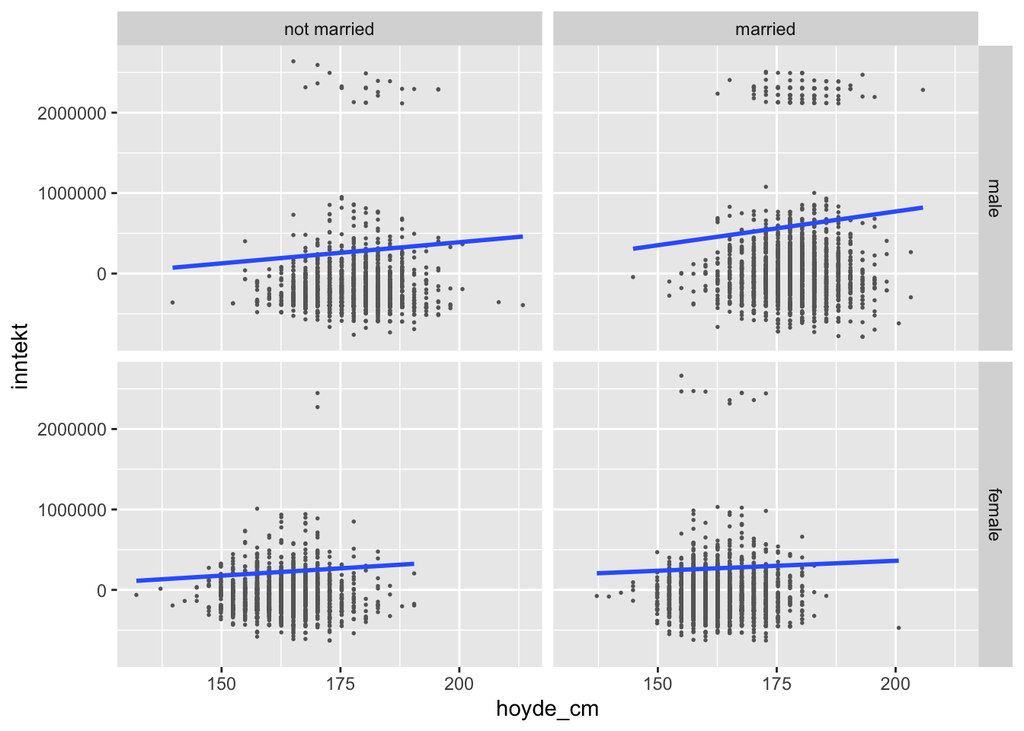

# Konklusjon

Med utgangspunkt i totalen av alle modellene kan vi konkludere med at høyde ikke har en reell påvirkning på inntekt. Inntekt vil være sammensatt av flere faktorer som spiller en større rolle enn fysisk høyde.

# Referanser

Judge, Timothy A., and Daniel M. Cable. 2004. “The Effect of Physical Height on Workplace Success and Income: Preliminary Test of a Theoretical Model.” *Journal of Applied Psychology* 89 (3): 428–41. https://doi.org/10.1037/0021-9010.89.3.428.